# Elaboração de Projetos de Investimento e Decisão Locacional

Empreendedorismo Tecnológico e Desenvolvimento Territorial · Aula 12

Prof. Dr. Luiz Diego Vidal Santos

## Unidade III Visão Geral da Aula

**01 · Ciclo do Projeto:** Elaboração de projetos de investimento (Woiler & Mathias, 2008).

**02 · Mercado e Escala:** Estudo de mercado e dimensionamento de tamanho/capacidade.

**03 · Decisão Locacional:** Macrolocalização e microlocalização no território.

**04 · Investimento Inicial:** Engenharia do projeto, investimentos fixos (CAPEX) e capital de giro.

**05 · Orçamento Operacional:** Estruturação de custos, despesas e receitas projetadas (OPEX).

Objetivo da Aula Engenharia econômica e território

Dominar as etapas técnicas de **elaboração de projetos de investimento**, destacando a **decisão locacional** como ponte direta entre a engenharia econômica e o planejamento territorial.

Ciclo de Projeto Decisão Locacional CAPEX & OPEX

# Ciclo do Projeto de Investimento

## Método Da Ideia ao Projeto Executivo (Woiler & Mathias, 2008)

01 · Perfil Identificação

Definição preliminar do problema, produto e escopo inicial do empreendimento.

02 · Filtro Pré-Viabilidade

Análise preliminar de mercado, tecnologia e custos para selecionar alternativas.

03 · Decisão Viabilidade Completa

Detalhamento técnico, econômico, ambiental e territorial para decidir o investimento.

04 · Execução Projeto Executivo

Engenharia detalhada, obras, aquisição de ativos e *start-up* operacional.

**Os 5 Estudos Básicos da Viabilidade:** (1) **Mercado** (demanda, oferta, preços); (2) **Tamanho / Escala** (capacidade instalada); (3) **Localização** (macrorregião e sítio); (4) **Engenharia do Projeto** (processo, *layout*, cronograma); e (5) **Análise Econômico-Financeira e Socioambiental**.

# Decisão Locacional no Território

## Território Fatores Locacionais: Ponte com o Planejamento Territorial

Escala Regional / Municipal Macrolocalização

- Proximidade de matérias-primas vs. mercado consumidor (orientação por peso e frete — Weber);
- Disponibilidade e qualificação de mão de obra;
- Infraestrutura energética, hídrica, logística e conectividade digital;
- Incentivos fiscais (SUDENE, estados, municípios) e **ecossistema de CT&I**.

Sítio Específico Microlocalização

- Zoneamento urbano e ambiental (Plano Diretor, ZEE, APPs);
- Custo do terreno, topografia, drenagem e licenciamento ambiental.

**Ponderação Locacional** (comparando municípios candidatos):

$$\text{Nota}_j = \sum_{i=1}^{n} w_i \cdot s_{ij}$$

onde $w_i$ é o peso do fator $i$ ($\sum w_i = 1$) e $s_{ij}$ é a pontuação do município $j$ no fator $i$.

Visão Crítica (PLANTERR) Externalidades Territoriais

A decisão locacional privada nem sempre internaliza externalidades (tráfego, pressão hídrica, segregação socioespacial); cabe ao planejamento territorial orientá-la.

## Decisão Esquema: Ciclo de Projetos e Decisão Locacional

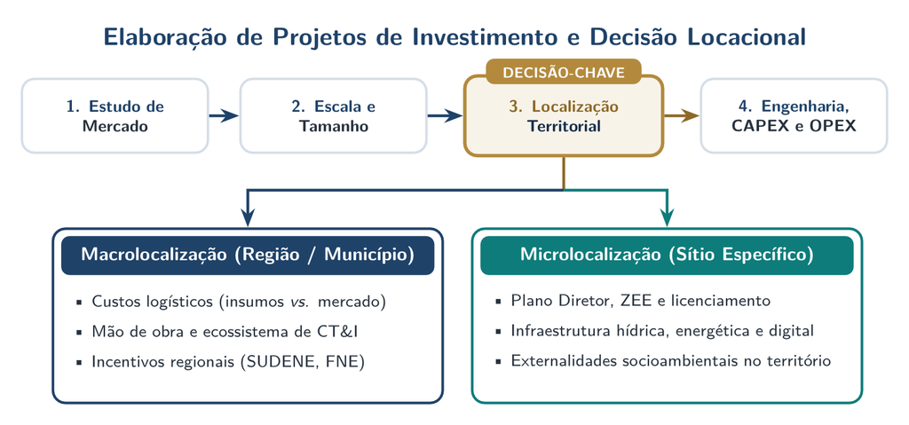

Articulação entre estudo de mercado, escala, macrolocalização/microlocalização territorial e estruturação de CAPEX/OPEX.

Articulação entre ciclo de elaboração de projetos e decisão locacional Estudo de mercado, dimensionamento de escala, macro/microlocalização territorial e CAPEX/OPEX

A escolha do sítio e da escala redefine diretamente custos logísticos, exigências ambientais e investimentos iniciais do projeto.

# Estrutura Econômica do Projeto

## Método CAPEX, Capital de Giro e OPEX

Investimento Inicial · Ano 0 CAPEX e Capital de Giro Líquido

- **CAPEX (Investimentos Fixos):** terrenos, edificações, máquinas, equipamentos, P&D capitalizado, licenças e software.
- **Capital de Giro Líquido (CGL):** recursos para financiar o ciclo operacional (estoques + contas a receber $-$ fornecedores).
- **Erro comum:** esquecer o capital de giro ou sua variação ($\Delta \text{CGL}$) nos anos de crescimento da receita.

Custos e Benefício Fiscal OPEX e Depreciação

- **Custos Variáveis** (proporcionais ao volume produzido) vs. **Custos Fixos**.
- **Depreciação:** não representa saída de caixa, mas **reduz a base de cálculo do Imposto de Renda**, gerando o benefício fiscal da depreciação ($+ D \cdot T$).

CAPEX, variação do CGL e benefício fiscal da depreciação alimentam diretamente o **Fluxo de Caixa Livre da Firma (FCFF)** analisado na próxima aula.

# Oficina e Leituras

## Síntese Matriz Locacional e Leituras

Exercício Prático · 35 min Matriz de Ponderação Locacional

Para o projeto escolhido pelo grupo, defina **5 critérios locacionais** (com pesos somando 100%) e compare **2 municípios ou zonas territoriais** candidatas a receber o empreendimento, justificando os trade-offs socioambientais e logísticos.

Próxima Aula Leituras Recomendadas

- **CASAROTTO FILHO, N.; KOPITTKE, B. H.** *Análise de investimentos* (Caps. sobre VPL, TIR, Payback e Análise de Risco).
- **ASSAF NETO, A.** *Finanças corporativas e valor* (Caps. sobre Custo de Capital e Decisões de Investimento).